# R code for Figure 1 - figure supplement 2 - Comparison with single nuclei RNA-seq

Xiao Xu (xxu@rockefeller.edu)

June 2018

Xu X, Stoyanova EI, Lemiesz A, Xing J, Mash DC, Heintz N (2018). Species and Cell-Type Properties of Classically Defined Human and Rodent Neurons and Glia.

Specifically, this workflow will generate a heatmap to accompany IGV tracks and figures relating to sequencing depth and comparison with single nuclei sequencing.

Load libraries and functions:

```r
# source custom functions
source("functions.R")
# libraries for heatmaps and colors
library(RColorBrewer)
library(gplots)
# libraries for data manipulation
library(reshape2)
# work in the tidyverse
library(tidyverse)
```

## Heatmap to accompany IGV tracks

Import counts and create metadata

```r
# read in table of counts
counts <- read_tsv("../data/mouse_gfp_antibody_wg_counts.txt") %>%
  select(Gene, contains("olig2"))
meta <- tibble(
  Sample = colnames(counts)[-1],
  Type = c("All", rep("Low", 2), rep("High", 2))
)
```

Normalize counts by length using FPKM (RPKM) calculation:

```r
# read in gene lengths
lengths <- read_tsv("../data/ref/mm10_refseq_wg_longest.txt",
                    col_names = c("Gene", "Length"))
# calculate rpkms
rpkms <- getNormCounts(counts, lengths, type = "RPKM")
```

Genes to visualize

```r
igv_genes <- c("Aldh1l1", "Olig2", "Pdgfra", "Cspg4", "Mag", "Mog")
rpkms_for_igv <- rpkms[igv_genes, ] %>% t()
```

Specify colors for heatmap:

```r
# palette
cor_col <- colorRampPalette( brewer.pal(9, 'YlOrRd') )(100)
cor_breaks <- seq(-2, 6, length.out = 101)
# sidebar for heatmap.2
cell_type_cols <- c(
  All = "black",
  Low = "#00CCCC",
  High = "#00FFFF"
)
sidebar_row <- rep(cell_type_cols, c(1, 2, 2))
```

Plot heatmap:

```r
pdf("../figures/figure_1_s2_heatmap_for_igv_oligo.pdf", width = 11, height = 8.5)
hm <- heatmap.2(
  rpkms_for_igv,
  dendrogram = "none", Rowv = FALSE, Colv = FALSE, # no dendrogram, no reordering
  col = cor_col, breaks = cor_breaks,  # colors for values
  RowSideColors = sidebar_row, # sidebar
  scale = "none", trace = "none",
  key.title = NA, key.ylab = NA,
  cexRow = 1, cexCol = 1, margins = c(2, 2),
  labCol = FALSE, labRow = FALSE, symkey = F,
  keysize = 1, key.par = list(mar = c(4, 2, 1, 1))
)
dev.off()
```

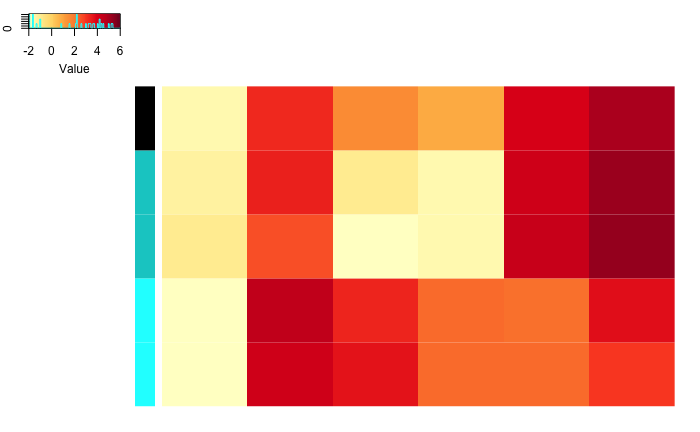

```r
# and display in this file
eval(hm$call)
```

## Single nuclei analysis

### Import counts and normalize

Import mouse glia counts and define metadata

```r
counts_sorted <- read_tsv("../data/mouse_gfp_antibody_wg_counts.txt") %>%
  select(Gene, contains("sept4"), contains("eaat1"), contains("olig2_"))
# create lookup table for cell types
lookup <- c(
  "sept4_gfp" = "b_glia",
  "eaat1" = "astro",
  "olig2_low" = "oligo",
  "olig2_high" = "opc"
)
meta_sorted <- tibble(
  Sample = colnames(counts_sorted)[-1]
) %>%
  separate(Sample, into = c("ID", "Gating"), sep = "_", remove = FALSE, extra = "merge") %>%
  mutate(Cell_type = lookup[Gating]) %>%
  mutate(Type = ifelse(grepl("gfp", Gating), "GFP", "AB")) %>%
  select(-Gating)
```

Import SN-Seq glia counts and define metadata. Raw sequence files were downloaded from GEO (GSE84371) for 17 astrocyte, 8 oligodendrocyte, and 7 OPC single nuclei mouse RNA-seq (sNuc-Seq) datasets from:

Habib N, Li Y, Heidenreich M, Swiech L et al. Div-Seq: Single-nucleus RNA-Seq reveals dynamics of rare adult newborn neurons. Science 2016 Aug 26;353(6302):925-8. PMID: 27471252

To directly compare these datasets to our bulk nuclear profiles for the same cell types, downloaded sequences were aligned to the mm10 genome and raw counts against mouse Refseq whole gene annotation were generated as described in the methods section of our manuscript.

```r
counts_sn <- read_tsv("../data/sn_counts.txt")
meta_sn <- tibble(
  Sample = colnames(counts_sn)[-1]
) %>%
  separate(Sample, into = c("Cell_type", "ID"), sep = "_", remove = FALSE) %>%
  mutate(Cell_type = gsub("asc", "astro", Cell_type)) %>%
  select(Sample, ID, Cell_type) %>%
  mutate(Type = "SN")
```

Merge metadata and counts and TPM normalize

```r
# read in gene lengths
lengths <- read_tsv("../data/ref/mm10_refseq_wg_longest.txt",
                    col_names = c("Gene", "Length"))
# tpm normalize
tpms_sorted <- getNormCounts(counts_sorted, lengths, type = "TPM_DV")
tpms_sn <- getNormCounts(counts_sn, lengths, type = "TPM_DV")
# merge
meta <- meta_sorted %>%
  bind_rows(meta_sn) %>%
  mutate(Type_ct = paste(Type, Cell_type, sep = "_"))
tpms <- tpms_sn %>%
  merge(tpms_sorted, by = "row.names") %>%
  rename(Gene = Row.names)
```

### ECDF plot

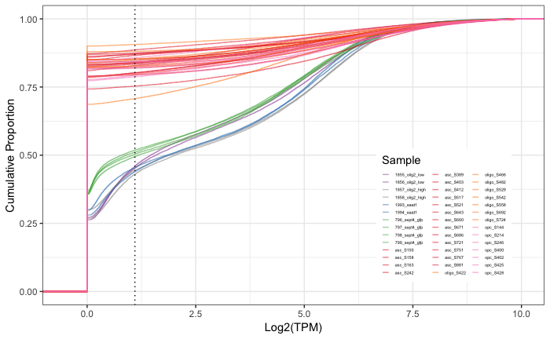

```r
# format data for plotting
tpms_melt <- tpms %>%
  melt() %>%
  rename(Sample = variable) %>%
  left_join(meta, by = "Sample")
# define colors
set1 <- brewer.pal(9, "Set1")
lookup <- c(
  AB_astro = set1[2],
  AB_oligo = set1[4],
  AB_opc = set1[9],
  GFP_b_glia = set1[3],
  SN_astro = set1[1],
  SN_oligo = set1[5],
  SN_opc = set1[8]
)
line_cols <- meta %>%
  mutate(Colors = lookup[Type_ct]) %>%
  pull(Colors)
names(line_cols) <- meta$Sample
# plot
ggplot(tpms_melt, aes(value)) +
  stat_ecdf(aes(color = Sample), alpha = 0.5, size = 0.5) +
  geom_vline(xintercept=1.1, linetype = "dotted") +
  scale_x_continuous(limits = c(-0.5, 10)) +
  scale_color_manual(values = line_cols) +
  ylab("Cumulative Proportion") +
  xlab("Log2(TPM)") +
  theme_bw() +
  theme(legend.position = c(0.8,0.3),
        legend.text = element_text(size=4),
        legend.key = element_rect(size = 2),
        legend.key.size = unit(0.5, 'lines'))
ggsaveToPdf("../figures/figure_1_s2_ecdf.pdf")
```

### Genes detected

Import subsampled counts

```r
counts_sub <- read_tsv("../data/sub_counts.txt")
meta_sub <- tibble(
  Sample = colnames(counts_sub)[-1]
) %>%
  separate(Sample, into = c("ID", "Cell_type", "Reads"), remove = FALSE) %>%
  mutate(Type = "AB") %>%
  mutate(Reads = as.numeric(Reads) * 1000) %>%
  select(Sample, ID, Cell_type, Type, Reads)
```

Calculate number of expressed genes for each sample

```r
# TPM normalize subsample counts
tpms_sub <- getNormCounts(counts_sub, lengths, type = "TPM_DV")
```

```
Setting row names on a tibble is deprecated.
```

```r
# calculate number of expressed genes
n_exp <- apply(tpms_sub, 2, function(x) length(x[x > 1.1]))
# merge with metadata
exp_sub <- meta_sub %>%
  mutate(Expressed = n_exp)
```

Import nubmer of reads for SN-seq datasets

```r
sn_mapped <- read_tsv("../data/sn_number_of_reads.txt")
n_exp <- apply(tpms_sn, 2, function(x) length(x[x > 1.1]))
exp_sn <- meta_sn %>%
  left_join(sn_mapped, by = "Sample") %>%
  mutate(Expressed = n_exp)
```

Plot

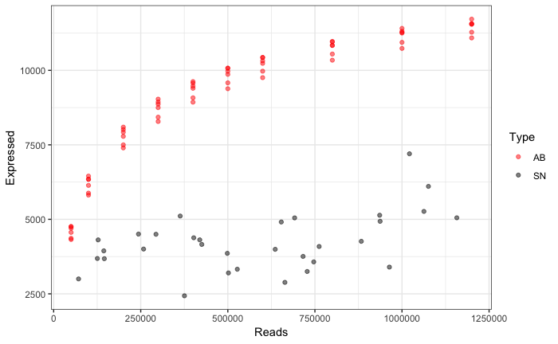

```r
exp_all <- exp_sub %>%
  bind_rows(exp_sn)
ggplot(exp_all, aes(x = Reads, y = Expressed)) +
  geom_point(aes(color = Type), alpha = 0.5) +
  scale_color_manual(values = c("red", "black")) +
  theme_bw()
ggsaveToPdf("../figures/figure_1_s2_genes_by_reads.pdf")
```

### Heatmap of gene expression

Read in marker genes and subset tpms for plotting

```r
# read in marker genes
marker_genes <- read_tsv("../data/sn_marker_genes.txt")
# only look at antibody-sorted and sn nuclei
meta_ab_sn <- meta %>%
  filter(Type != "GFP") %>%
  arrange(desc(Type))
# subset tpms by marker genes
tpms_markers <- tpms %>%
  select(Gene, meta_ab_sn$Sample) %>%
  filter(Gene %in% marker_genes$Gene)
# reorder
tpms_ab_max <- apply(tpms_markers[, !grepl("_S|Gene", colnames(tpms_markers))], 1, max)
tpms_ordered <- tpms_markers %>%
  mutate(Max = tpms_ab_max) %>%
  left_join(marker_genes, by = "Gene") %>%
  arrange(Cell_type, desc(Type), desc(Max)) %>%
  select(-c("Max", "Cell_type", "Type")) %>%
  column_to_rownames("Gene") %>%
  as.matrix()
```

Plot heatmap

```r
# set heatmap colors
hm_cols <- colorRampPalette( brewer.pal(9, "Oranges") )(100)
hm_breaks <- seq(0, 12, length.out = 101)
# save to pdf
pdf("../figures/figure_1_s2_exp_heatmap.pdf", width = 11, height = 8.5)
hm <- heatmap.2(
  tpms_ordered,
  dendrogram = "none", trace = "none",
  Rowv = FALSE, Colv = FALSE,
  col = hm_cols, breaks = hm_breaks
)
dev.off()
```

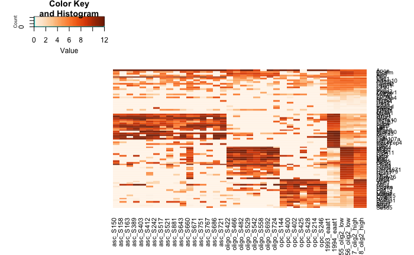

```r
# and display in this file
eval(hm$call)
```